# Project 2: Modelling daily cycling demand in Edinburgh

Group members: Alice Miller, Saba Sitter, Jake Saunders

# Introduction

The “cycle daily” dataset consists of approximately 2,180 daily observations ranging from 2020 to 2025, sourced from Edinburgh’s network of automatic cycling counters, along with local weather and temporal data. This data comes from sensors at specific locations across the city, so it’s possible not every cyclist is accounted for. Similarly, some cyclists may pass through multiple sensors in a day and be observed more than once. However, they are a good indicator of how cycling demand varies across different days and weather patterns. Edinburgh relies heavily on public transport for its residents and tourists to navigate the city. For future funding allocation and planning, it is important to know how many cyclists are on the road in order to evaluate whether the infrastructure (cycle lanes, crossings etc) and investment in schemes (eg rentable Voi bikes) need to adapt to meet demand. The modelling goal is to develop a sequence of increasingly complex linear regression models to isolate how temporal and weather variables, such as the day of the week and the temperature, influence cycling demand. Ultimately, the goal is to extrapolate cycling demand so that Edinburgh City Council and Transport Scotland can optimise infrastructure investment over the next decade to align with their active travel priorities.

# Exploratory data analysis

To begin investigating the impact of weather on the number of daily cyclists, we begun with some exploratory data analysis. This involved converting month to an ordered factor, redefining the day of week predictor with explicit levels. Additionally, we created a new variable ‘trend’ which symbolises the number of days since the first observation (01/01/2020), along wtih binary indicators ‘is_covid’ and ‘is_holiday’ which represent the UK Covid lockdown (23/03/2020 - 31/03/2021) and the yearly festive period (24th - 31st December) respectively.

We initially found the summary statistics for the number of daily cyclists and the weather data.

Summary Statistics for count, temp mean, temp min, temp max

| Variable | Mean | SD | Min | Max |
| --- | --- | --- | --- | --- |
| count | 10815.47 | 4728.88 | 1264.00 | 43864.00 |
| temp_mean | 9.69 | 4.79 | -8.08 | 22.96 |
| temp_min | 5.92 | 4.98 | -14.00 | 18.00 |
| temp_max | 13.15 | 5.31 | -3.00 | 31.00 |

We can see that the number of daily cyclists varies from $1,264$ to $43,864$, a variation of $\approx 3370 \%$. Intuitively, one would think that a warmer average weather would lead to more cyclists.

We then plotted a time series of the daily cyclist count over the period of observations.

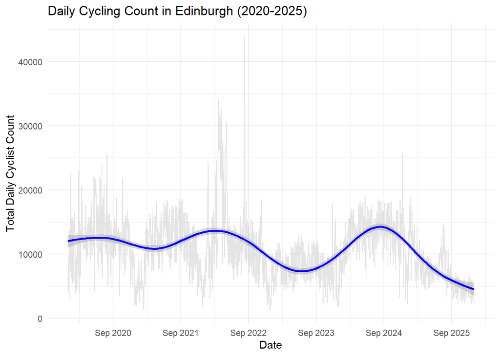

Time series of daily cyclist counts 2020-2025

We then created boxplots of the daily cyclist count by month and by the day of week to observe whether they had any significant impact on the number of daily cyclists.

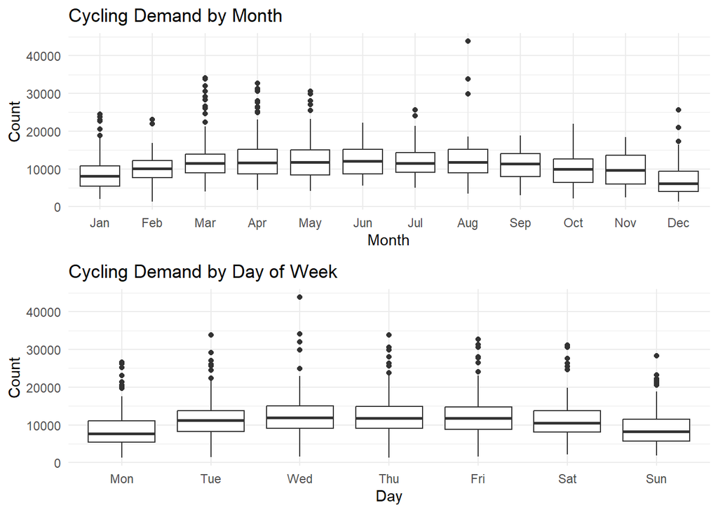

Boxplots of cyclist count by month and day of week

We can see from Figure 2 that the colder months (October - February) have slightly lower cyclist counts, with the other months remaining relatively constant. There are a lot of outliers, especially in Spring. Observations with unusually high cyclist counts could be attributed to special events such as races, bank holidays, and exceptionally sunny days. Outside of winter, the month doesn’t appear to have a tremendous impact on the median daily cyclist count.

The second boxplot indicates that there tends to be less cyclists on Mondays and Sundays, with the other days appearing relatively constant.

We then plotted the daily cyclist count against the mean temperature, with red and blue lines indicating regression and quadratic relationship respectively.

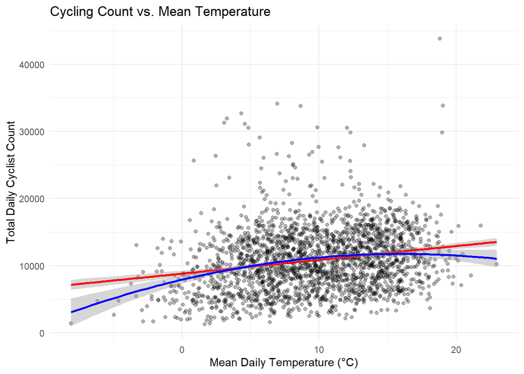

Daily cyclist count vs mean temperature

There is a visible positive correlation between temperature mean and daily cyclist count, which was to be expected. There are less observations for the days with the lowest and highest mean temperatures, so there is not a clear trend that we can see for those days. There is a large variation in cyclist counts for days with the same temperature, so it is not feasible to predict counts based off of mean temperature alone.

We noticed dips in cyclist numbers between Christmas Eve and New Years Eve, presumably due to less commuters on the road. We created the following graph to illustrate this over the course of the 5 years.

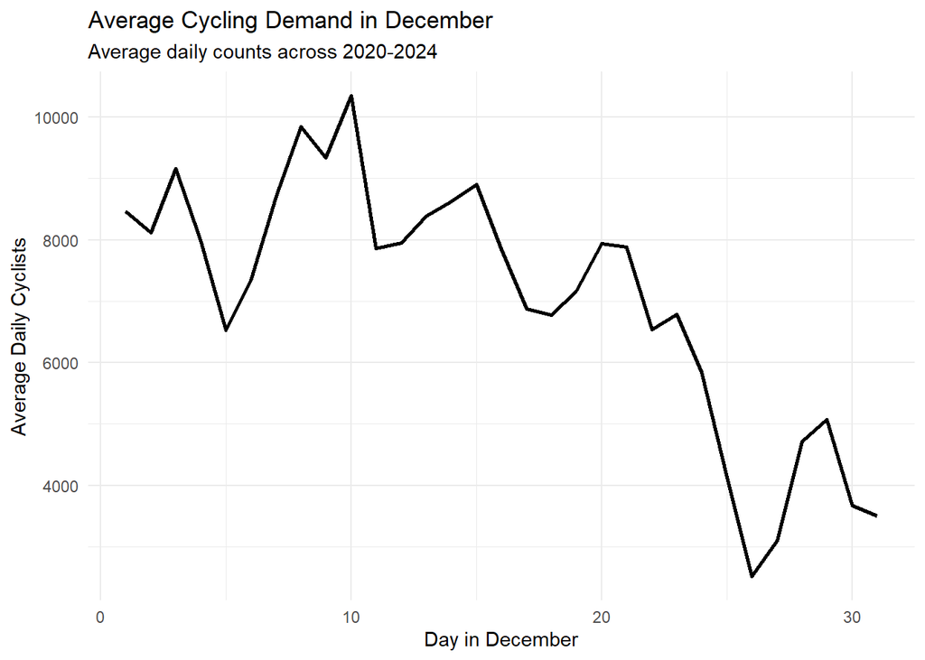

Line Graph of average daily cyclists in decemeber

Clearly, there is a substantial decrease in cyclist numbers between the specified days. This led us to add whether a day falls between the 24th and 31st of December in our final model as ‘is_holiday’.

We also created a chart that demonstrates the effect of whether a day is lockdown on daily cyclist counts.

# Baseline model

We fit an initial model, M0, that uses the mean temperature, along with the month and whether it is a weekend in order to predict the daily cyclist count.

The equation for M0 is:

#
$$\text{count}_i = \beta_0 + \beta_1
\text{temp_mean}_i + \beta_2 \text{weekend}_i + \beta_3 \text{month}_i +
\epsilon_i$$
#
$$\epsilon_i \sim N(0,
\sigma^2)$$

The following table shows the summary statistics for M0:

Summary of M0

|  | Estimate | Std. Error | t value | Pr(>\|t\|) |
| --- | --- | --- | --- | --- |
| (Intercept) | 10385.8188 | 267.01547 | 38.895944 | 0 |
| temp_mean | 247.1791 | 20.76877 | 11.901478 | 0 |
| as.numeric(weekend) | -1246.8883 | 214.17220 | -5.821896 | 0 |
| as.numeric(month) | -247.1840 | 28.80970 | -8.579887 | 0 |

For every 1 degree increase in the mean daily temperature, the model predicts an increase of 247 cyclists per day, and predicts a 1247 decrease in cyclist count on weekends compared to weekdays. Since M0 uses month as a numeric predictor, it ignores the fact that cyclist counts generally increase in summer and fall in winter. Currently, the model suggests that there is a decrease of 247 cyclists for each month passing.

We then assessed the diagnostic plots for M0.

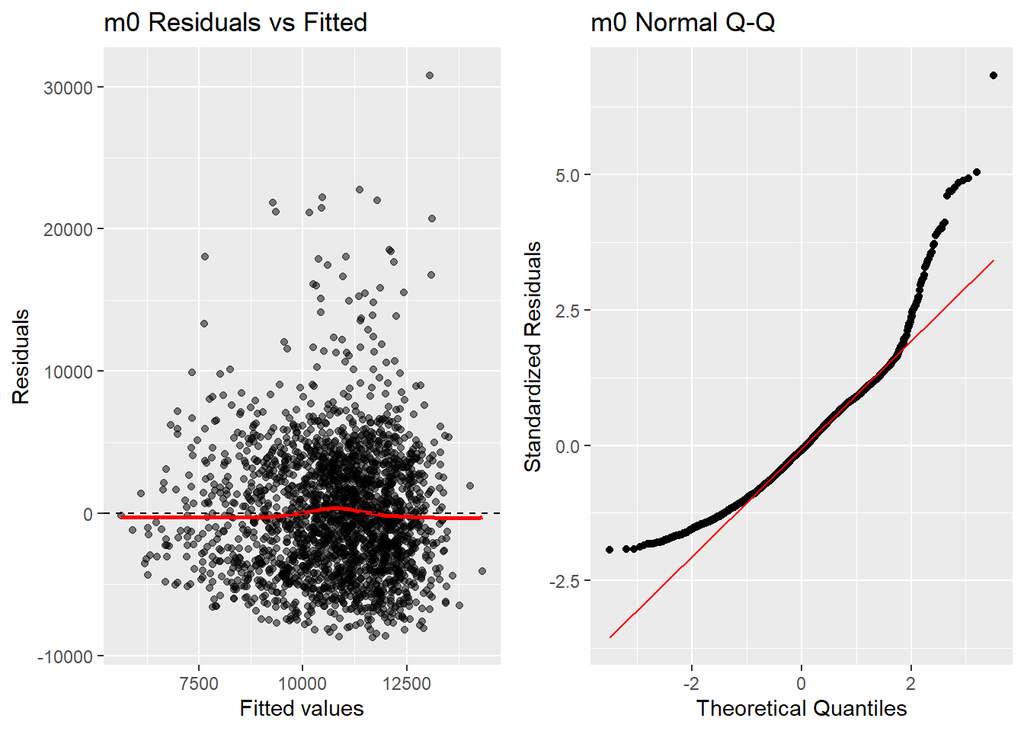

Diagnostic plots for M0

Model 0 (m0) shows a mean variance of 0, independent of the fitted values. The residuals show a non-linear pattern, with an arguable ‘n’ shape above the mean line, indicating there is an underlying non-linear structure yet to be included in our model.

The QQ plot demonstrates right skewing and heavy tail in the positive quantiles - thus the normality assumption for linear regression is violated. This indicates the model is particularly bad at predicting high count observations.

# Model M1

We created a further model, M1, which adds in the trend variable as a predictor to capture the drift in cycling levels over 2020-2025.

Our proposed equation for M1 (identifiable form) is:
$$\text{count}_i = \beta_0 + \beta_1
\text{temp_mean}_i + \beta_2 \text{trend}_i + \sum_{j=2}^{12} \gamma_j
\mathbb{I}(\text{month}_i = j) + \sum_{k=2}^{7} \delta_k
\mathbb{I}(\text{dow}_i = k) + \epsilon_i$$

$$\epsilon_i \sim N(0,
\sigma^2)$$

Day 1 (Monday) and month 1 (Jan) are encapsulated in the intercept term $\beta_0$ Every other month or day is measured as the expected difference in count from the baseline.

We investigate m1 over m0 because m1 has the granularity for the effect of different weekdays rather than simplistic weekend or non weekend effects. Changing ‘month’ to a factor variable allows for building a seasonal profile rather than assuming the month index (1-12) is linear with the count. We omit the weekend term and numerical version of ‘month’ to avoid collinearity with their ‘factor’ versions and because the covariate ‘dow’ is collinear with ‘weekend’.

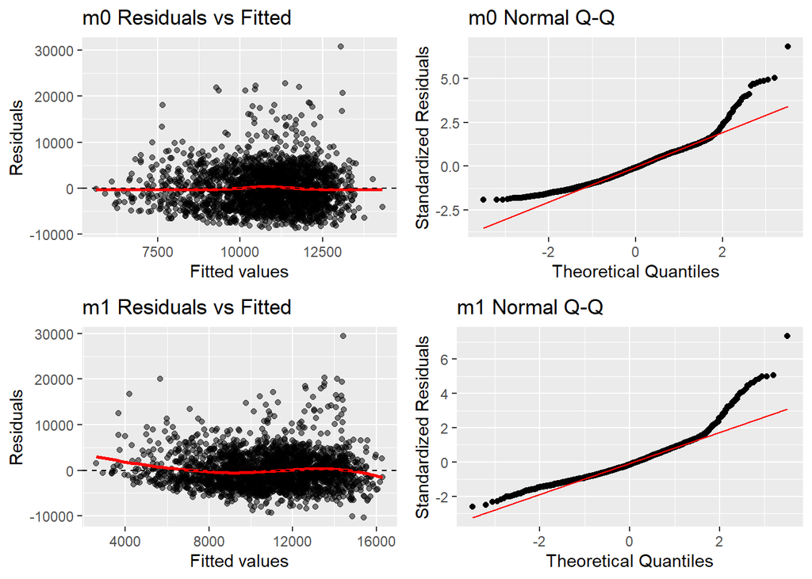

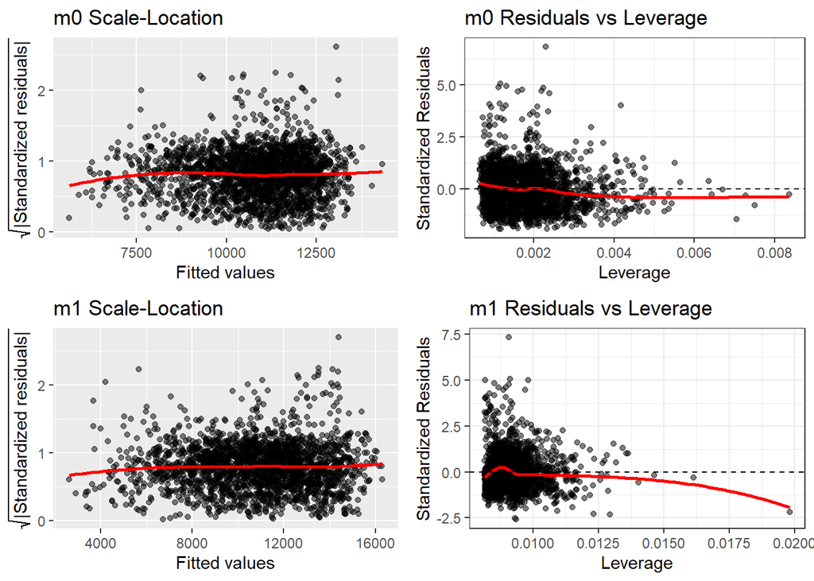

Plot grid 1: Observe in the bottom left, the mean residual line follows a slight sigmoid shape, suggesting the linear assumption is still violated for model 1. On a positive note, the ‘n’ pattern about the mean is less pronounced for model 1. The bottom right Q-Q plot looks slightly more aligned to the normal line at the lower tail (compared to M0). This suggests the prediction for the low count days is better.

Plot grid 2: Observe the leverage and thus influence is larger for the outliers of m1.

## Model M2: Nonlinear temperature

Our proposed equation for M2 (identifiable form) is:
$$\text{count}_i = \beta_0 + \beta_1
\text{temp_mean}_i + \beta_2 \text{temp_mean}^2_i + \beta_3
\text{trend}_i + \sum_{j=2}^{12} \gamma_j \mathbb{I}(\text{month}_i = j)
+ \sum_{k=2}^{7} \delta_k \mathbb{I}(\text{dow}_i = k) +
\epsilon_i$$
$$\epsilon_i \sim N(0,
\sigma^2)$$

From the temperature vs count scatter plot, we see there is an underlying some non linear relationship as we can see some curvature. Hence, if we add the quadratic ‘mean temperature’ term to model m1, the underlying structure maybe better covered by the model:

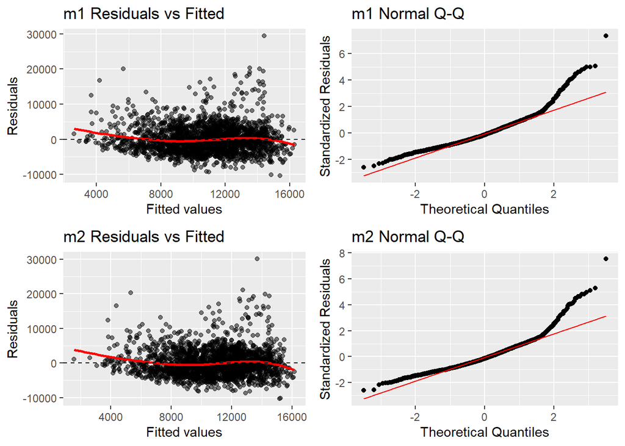

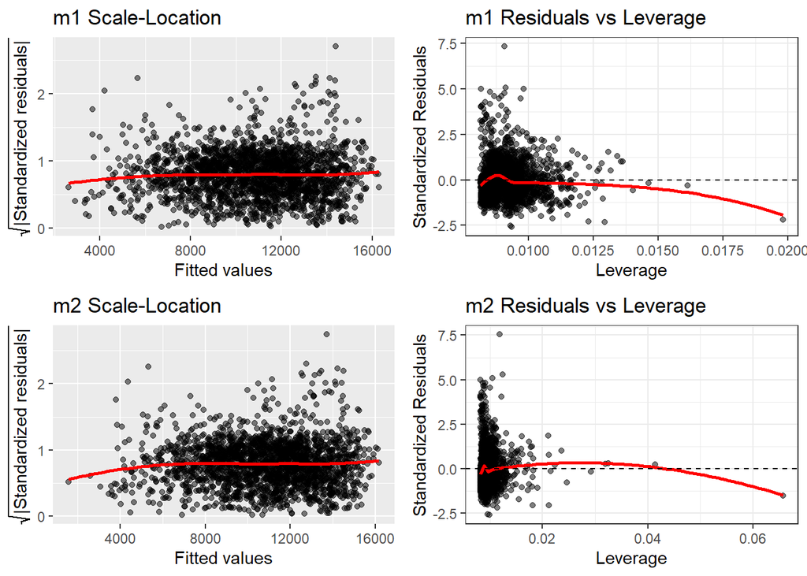

The expression is:
$$\log(count_i + 1) =
\beta_0 + \beta_1 temp\_mean_i + \beta_2 temp\_mean_i^2 + \beta_3
trend_i + \sum_{j=2}^{12} \gamma_j \mathbb{I}(month_i = j) +
\sum_{k=2}^{7} \delta_k \mathbb{I}(dow_i = k) + \beta_4 is\_covid_i +
\beta_5 is\_holiday_i + \epsilon_i$$
$$\epsilon_i \sim N(0, \sigma^2)$$

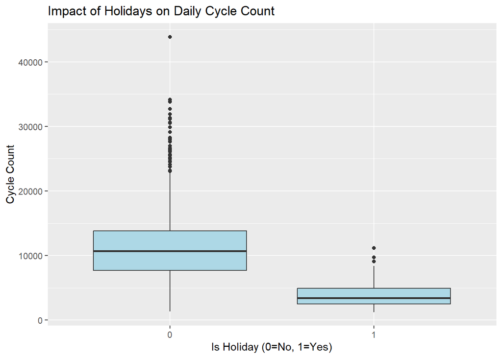

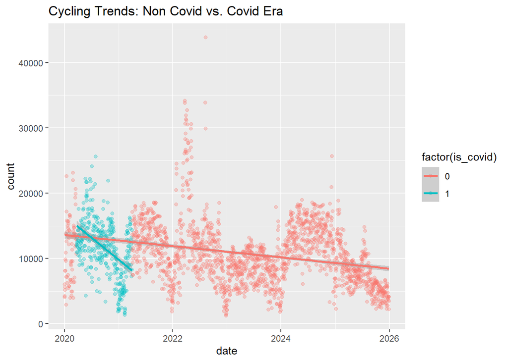

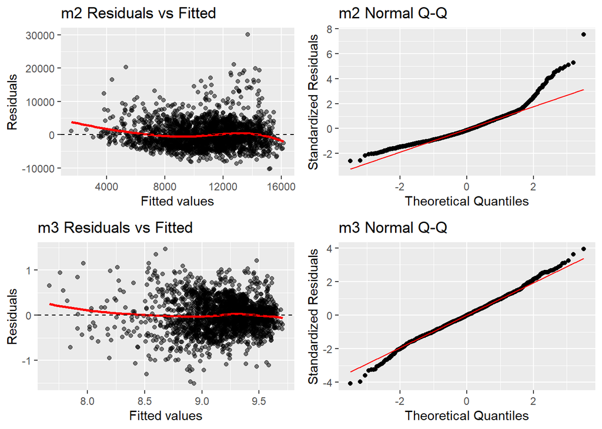

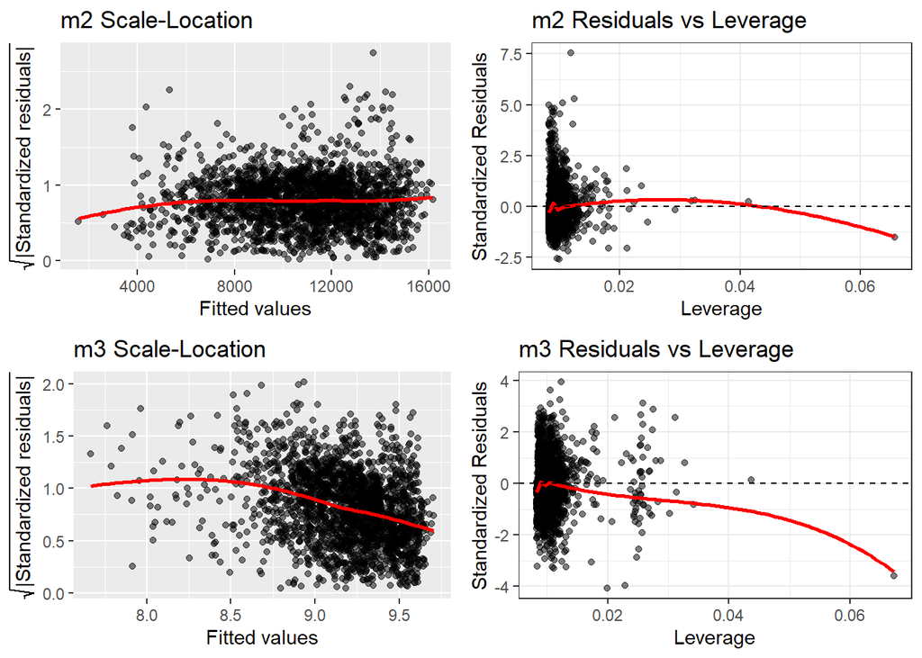